# FDP-on Transformers to Agentic AI

Author

Affiliation

Arundev Vamadevan

Associate Faculty Lecturer, National College of Ireland

# 1 Hands-on Workshop on Foundational Language Models and Fine-Tuning

Welcome to this FDP program.  
You can also access this file online using the QR code below.

## 1.1 About me

| **Field** | **Details** |
| --- | --- |
| **Name** | Arundev Vamadevan |
| **Designation** | Associate Faculty Lecturer and Research Supervisor, National College of Ireland, Dublin |
| **Email** | Arundev.Vamadevan@ncirl.ie |
| **LinkedIn** | [LinkedIn Profile](https://www.linkedin.com/in/arundev-v) |

## 1.2 Scan the QR Code to Access This File

[figure not shown]

**Or visit directly:** https://arundev-genai.github.io/transformers-to-agentic-ai/

# 2 Workshop Introduction & Agenda

Welcome to the Hands-On Workshop on Modern Language Models & Fine-Tuning Techniques.  
In this session, we will explore the latest advancements in Foundational Language Models (FLMs) and learn how to fine-tune LLMs efficiently, both theoretically and practically.

This workshop is designed to give you:

✔ A clear understanding of how today’s leading language models work  
✔ Hands-on experience running these models locally using Ollama and Hugging Face  
✔ Practical knowledge of parameter-efficient fine-tuning, including LoRA and P-Tuning  
✔ End-to-end workflows for inference, embeddings, and fine-tuning  
✔ Real-world coding examples you can reuse in your research or projects

## 2.1 Part 1 — Foundational Language Models

We begin by understanding what Foundational Language Models (FLMs) are and how they differ from regular Large Language Models (LLMs).  
We will explore different categories of FLMs based on:

- Model size (small, medium, large)
- Use case (chat, coding, embeddings)
- Architecture (Mixture-of-Experts, decoder-only transformers, small language models)
- Local usage (Ollama, CPU/GPU compatibility)

### 2.1.1 Models Covered

🔹 **LLaMA 3 Family**

- LLaMA 3 Instruct 8B / 70B — instruction-tuned general-purpose models
- LLaMA 3 Chat — conversational AI models
- LLaMA 3 Code — optimized for programming tasks

🔹 **Embedding Model**

- E5 Embedding Models — high-quality embeddings for RAG, clustering, similarity search

🔹 **Mixture-of-Experts (MoE)**

- Mixtral 8x7B — sparse MoE architecture for high-performance inference

🔹 **Small Language Models (SLMs)**

- PHI-3 — compact, high-efficiency SLM suitable for edge devices
- BitNet B1.58 — bit-based efficient transformer for ultra-low-resource environments

### 2.1.2 Hands-On (Part 1)

- Running LLaMA 3, Mixtral, PHI-3 locally using Ollama
- Using E5 models with Hugging Face Sentence Transformers
- Chat generation, coding tasks, document understanding
- Building a small RAG pipeline
- Comparing performance of SLMs vs LLMs

## 2.2 Part 2 — LLM Fine-Tuning Techniques

In the second half, we dive into how to adapt large models for specific tasks using modern, efficient techniques.

We explore:

- Why full fine-tuning is expensive
- How parameter-efficient methods reduce cost by 10–100×
- Practical implementation using Hugging Face Transformers and PEFT

### 2.2.1 Techniques Covered

🔹 **Parameter-Efficient Fine-Tuning (PEFT)**  
A framework enabling efficient adaptation of large models with minimal trainable weights.

🔹 **LoRA (Low-Rank Adaptation)**  
The most widely used PEFT technique—fast, memory-efficient, and production ready.

🔹 **P-Tuning / Prompt Tuning**  
Train soft prompts instead of model weights; lightweight but powerful.

🔹 **Full Fine-Tuning (optional)**  
Understand the traditional approach—useful for research contexts.

🔹 **Fine-Tuning Embedding Models**  
How to customize embedding representation for domain-specific retrieval tasks.

### 2.2.2 Hands-On (Part 2)

- Implement LoRA fine-tuning on a lightweight LLM
- Compare LoRA vs Full Fine-Tuning
- Parameter-efficient training using Hugging Face PEFT
- Fine-tuning a small embedding model (E5 or BERT-based)
- Running the fine-tuned model locally on Ollama (via GGUF)
- Evaluation: perplexity, accuracy, semantic similarity

## 2.3 Workshop Outcome

By the end of the workshop, participants will:

✔ Understand the landscape of modern language models  
✔ Know how to run LLMs locally on laptops (via Ollama + HF)  
✔ Be able to perform inference, embeddings, and RAG  
✔ Know how to fine-tune LLMs using LoRA, P-Tuning, and PEFT  
✔ Gain reusable code for research and development  
✔ Build confidence in working with state-of-the-art LLM techniques

# 3 What is a Language Model?

## 3.1 Simple Definition

A Language Model (LM) is a computer program that learns patterns in language and can predict or generate text—just like how humans guess the next word in a sentence.

**Example:**  
“I am going to the …” → a language model may predict “store”, “park”, “gym”, etc.

## 3.2 How a Language Model is Built

**1. Collect text data**  
The model is trained on books, articles, websites, chats, code, etc.

**2. Convert text into numbers**  
Words/sentences get converted into vectors (numbers) using embeddings.

**3. Train a neural network**  
A transformer-based network learns:

- grammar
- meaning
- reasoning patterns
- next-word predictions

**4. The model improves by seeing millions/billions of examples**  
It learns how humans use language.

## 3.3 Technical Architecture

Most modern language models use a structure called **Transformer**.

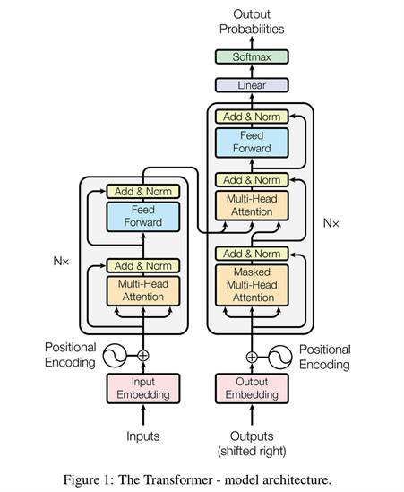

Transformer Architecture

**Source:** [Attention is All You Need](https://arxiv.org/abs/1706.03762)

## 3.4 Transformer Architecture

The Transformer Architecture, introduced in the 2017 *Attention Is All You Need* paper, changed how we build large language models. Unlike earlier NLP models that process text one word at a time, transformers can look at **all the words in a sentence simultaneously**. This is possible because of **attention**, which helps the model understand how each word relates to every other word, regardless of position.

During training, the model learns **attention weights**—scores that indicate which words are more important when making predictions. Because transformers process words in parallel instead of sequentially, they are significantly faster and more efficient.

### 3.4.1 Key Ideas That Make Transformers Powerful

- **Self-Attention**  
  Helps the model understand how each word connects to all other words in the sentence. Over time, the model forms an internal understanding of language.
- **Positional Encoding**  
  Since transformers don’t naturally read text in order, positional encoding adds information about word order to the input, helping the model interpret sequence structure.

Transformers are also considered **semi-supervised models**, as they are first pre-trained on massive unlabelled datasets and later fine-tuned using labelled data.

### 3.4.2 High-Level Structure

Transformers consist of two major components:

- **Encoder**
- **Decoder**

Both rely on shared components such as tokenisation, embeddings, positional encodings, self-attention layers, and feed-forward networks.

## 3.5 Difference Between LM, SLM, LLM, and Foundational Language Model

Below is a very simple, beginner-friendly explanation of the different types of language models.

### 3.5.1 A) Language Model (LM)

A **Language Model (LM)** is a general term for any model that can understand or generate human language.

**Key Points:** - Can be *small or large* - Can use old architectures (RNN, LSTM) or modern ones (Transformers) - Used for predicting or generating text

**Examples:** GPT-2, BERT, GPT-Neo

### 3.5.2 B) Small Language Model (SLM)

An **SLM** is a *compact* language model designed for efficiency.

**Key Points:** - Can run on smaller devices (laptops, phones, Raspberry Pi) - Uses fewer parameters (usually < 1B–3B) - Fast, efficient, and cheaper to train - Lower reasoning ability than LLMs

**Examples:** - PHI-3  
- BitNet B1.58  
- LLaMA 3.2 1B  
- Gemma 2B

### 3.5.3 C) Large Language Model (LLM)

An **LLM** is a *large-scale* model trained on massive datasets.

**Features:** - Strong reasoning and problem-solving ability  
- High-quality text generation  
- Supports complex tasks (coding, math, planning)  
- Typically 7B–70B+ parameters

**Examples:** - LLaMA 3 8B / 70B  
- Mixtral 8x7B  
- GPT-3.5 / GPT-4  
- Claude 3

### 3.5.4 D) Foundational Language Model (FLM)

A **Foundational Model** is a very large, general-purpose model trained on huge and diverse datasets that can be adapted (fine-tuned) for many downstream tasks.

**Key Points:** - Broad, general-purpose capabilities - Acts as a base model for specialized versions - Usually trained on multimodal or extremely large datasets

**Examples:** GPT-4, LLaMA-3, Claude Opus, Gemini 1.5

## 3.6 Categorized by USE CASE / FUNCTIONAL SPECIALIZATION

### 3.6.1 (1) General-purpose Instruction Models

Designed for reasoning, answering queries, and conversational AI.

**Examples:** - LLaMA 3 Instruct 8B  
- LLaMA 3 Instruct 70B  
- Mixtral 8x7B  
- PHI-3  
- BitNet B1.58

### 3.6.2 (2) Chat-optimized Models

Built specifically for dialog, memory, and multi-turn conversation.

**Examples:** - LLaMA 3 Chat 8B  
- LLaMA 3 Chat 70B  
- PHI-3 Chat versions

### 3.6.3 (3) Code Generation Models

Optimized for coding, debugging, and code completion in languages like Python, JavaScript, and Java.

**Examples:** - LLaMA 3 Code 8B  
- LLaMA 3 Code 70B

### 3.6.4 (4) Embedding Models

Used for Retrieval-Augmented Generation (RAG), semantic search, and vector databases.

**Examples:** - E5 Embedding Model Family  
- e5-small  
- e5-base  
- e5-large

### 3.6.5 (5) Efficiency-Focused / Small Language Models (SLMs)

Used for low-power devices or edge deployment.

**Examples:** - PHI-3  
- BitNet B1.58 (binary-weight efficient model)

## 3.7 Practical Session: Working with LLMs using Ollama & Hugging Face

In this hands-on session, we will explore how to run and experiment with modern Language Models both **locally** (using Ollama) and **from the cloud** (using Hugging Face).

## 3.8 LLM Application using Ollama (Python Program)

```python
import ollama

def generate_text(promt):
    result = ollama.generate(model='llama2', prompt=promt)
    return result['response']

def question_answer(question):
    prompt = f'Answer the question concisely : {question}'
    result = generate_text(prompt)
    return result

def summarize(paragraph):
    prompt = f'summarize the below paragraph into 2 sentence: {paragraph}'
    result = generate_text(prompt)
    return result

def lang_translate(sentence, language):
    prompt = f'convert the below sentence {sentence} in to {language} language'
    result = generate_text(prompt)
    return result

print("LLM Application NLP Tasks")
print("1. Generate Text")
print("2. Question Answring")
print("3. Summary of a paragraph")
print("4. Language Translation ")
print("Enter your choice")

choice = input("1/2/3/4")

if choice == '1':
    prompt = input("Enter your prompt here")
    result = generate_text(prompt)

elif choice == '2':
    question = input("Enter your question here")
    result = question_answer(question)

elif choice == '3':
    paragraph = input("Enter the paragraph to summarize")
    result = summarize(paragraph)

elif choice == '4':
    sentence = input("Enter the sentence to translate")
    language = input("Enter the language")
    result = lang_translate(sentence, language)

else:
    result = "Wrong Choice !!!"

print("Result : ", result)
```

## 3.9 Example Tasks using Hugging Face `transformers` Pipeline

```python
# Task 1: Sentiment Analysis
from transformers import pipeline

classifier = pipeline("sentiment-analysis")
result = classifier("I was happy to visit my home country")
print(result)

# Task 2: Text Generation
from transformers import pipeline

text_generator = pipeline("text-generation", model="distilbert/distilgpt2")
generated_text = text_generator(
    "Today is a rainy day in London",
    truncation=True,
    num_return_sequences=2
)
print("Generated_text:\n", generated_text)

# Task 3: Question Answering
from transformers import pipeline

qa_model = pipeline("question-answering")
question = "What is my job?"
context = "I am developing AI models with Python."
print(qa_model(question=question, context=context))
```

## 3.10 Research Paper Summarizer using LLMs (Hugging Face + arXiv API)

```python
import arxiv
import pandas as pd
from transformers import pipeline

# Query arXiv for AI / ML papers
query = 'ai OR artificial intelligence OR machine learning'
search = arxiv.Search(
    query=query,
    max_results=10,
    sort_by=arxiv.SortCriterion.SubmittedDate
)

# Extract metadata from results
papers = []
for result in search.results():
    papers.append({
        'published': result.published,
        'title': result.title,
        'abstract': result.summary,
        'categories': result.categories
    })

# Convert to DataFrame
df = pd.DataFrame(papers)
pd.set_option('display.max_colwidth', None)

# Display the first 10 papers
df.head(10)

# Example: take first abstract
abstract = df['abstract'][0]

# Load summarization model
summarizer = pipeline("summarization", model="facebook/bart-large-cnn")

# Summarize abstract
summarization_result = summarizer(abstract)
summarization_result[0]['summary_text']
```

## 3.11 LLM Augmentation

LLM (Large Language Model) Augmentation refers to techniques used to enhance the capabilities of large language models by integrating external data sources, retrieval mechanisms, fine-tuning strategies, or computational methods to improve their accuracy, relevance, and contextual understanding.

### 3.11.1 Techniques of LLM Augmentation

#### 3.11.1.1 Retrieval-Augmented Generation (RAG)

- Combines LLMs with an external knowledge base to fetch relevant information before generating a response.

#### 3.11.1.2 Fine-Tuning & Parameter Efficient Fine-Tuning (PEFT)

- Fine-tuning the model using domain-specific datasets to improve its performance in a particular task.

**Techniques:** - Full fine-tuning - LoRA (Low-Rank Adaptation) - QLoRA (Quantized LoRA) - Prefix Tuning

#### 3.11.1.3 Prompt Engineering & Prompt Tuning

- Optimizing input prompts to get more accurate and relevant responses from the model.

**Techniques:** - Zero-shot, Few-shot, and Chain-of-Thought (CoT) prompting - Self-consistency prompting - Prompt tuning with soft tokens

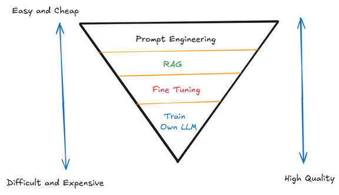

LLM Augmentation

## 3.12 Choosing the Right Optimization

### 3.12.1 Time is a Constraint

- Start with **Prompt Engineering** — it’s fast, easy to experiment with, and requires no model changes.

### 3.12.2 If You Need Real-Time Data

- Use **RAG (Retrieval-Augmented Generation)** to fetch external or frequently updated information, ideal for apps like:
  - Customer support
  - Semantic search
  - Financial dashboards

### 3.12.3 If You Need High Accuracy and Efficiency

- **Fine-tune the model** when you want to reduce latency and token costs for well-defined, repetitive tasks like:
  - Legal compliance checks
  - Automated reporting

### 3.12.4 Best Practice

- The best practice is to **combine all three techniques** to get the most out of your LLM:
  - **Prompt Engineering** helps you prototype and test prompts quickly
  - **RAG** ensures that your model has access to the latest external information
  - **Fine-Tuning** makes the model more efficient for domain-specific tasks by reducing token usage and improving accuracy

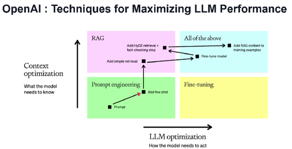

Best Practise

[Source : Optimizing LLM Accuracy – OpenAI Documentation](https://platform.openai.com/docs/guides/optimizing-llm-accuracy)

## 3.13 Training Own Model for LLM Optimization

### 3.13.1 Why Train from Scratch?

- If you need **deep, specific domain knowledge** without any bias from pre-existing models
- If your **data or the use case is unique**, this approach provides more precise and controlled outcomes
- In **sensitive industries**, having a model trained entirely on internal data can help meet stringent compliance requirements

### 3.13.2 Drawbacks of Training from Scratch

- Requires substantial **computational power, storage**, and sometimes **weeks to complete**
- **High-quality and large-scale data** is essential, which can be costly and time-consuming to collect
- Need **specialized skills** in deep learning, hyperparameter tuning, and model optimization
- This process is **lengthy** compared to fine-tuning or prompt engineering

### 3.13.3 Fine-tuning LLMs

- **Fine-tuning** is the process of taking a **pre-trained machine learning model** and further training it on a **specific dataset** to adapt it for a particular task or domain.
- The model is already trained on large amounts of data but needs to be **optimized for domain-specific knowledge**.

[figure not shown]

Fine-Tuning

## 3.14 Key Benefits of Fine-Tuning

### 3.14.1 Domain Adaptation

- Pre-trained models do not inherently understand **proprietary information** or **specialized terminology**.
- Example: They won’t recognize your company’s latest product features unless fine-tuned on relevant documentation and data.

### 3.14.2 Enhanced Performance in Niche Tasks

- Fine-tuned models can handle **domain-specific tasks** such as:
  - Legal document review
  - Medical record summarization
  - Technical support automation
- Achieves **higher accuracy** for these specialized tasks.

### 3.14.3 Cost Optimization

- Fine-tuning a **smaller, efficient model** (e.g., gpt-4o-mini) can:
  - Reduce dependency on **larger, costlier models** like gpt-4o
  - Still achieve **high accuracy** for specialized use cases

### 3.14.4 Workflow Alignment

- Fine-tuning aligns the model’s behavior with:
  - **Domain-specific workflows**
  - **Data structures**
  - **Terminology**
- Ensures **seamless integration** into business processes

## 3.15 Types of Fine-Tuning

### 3.15.1 1 Full Fine-Tuning

**What it is:**  
- You train **all the parameters** of the model on your new dataset.  
- The model fully “adapts” to the new task.

**Pros:**  
- Maximum flexibility — can learn very specific tasks.  
- Can achieve high accuracy if you have lots of data.

**Cons:**  
- Very expensive in compute and memory, especially for large models (e.g., 70B LLaMA).  
- Slow to train.  
- Hard to store multiple fine-tuned versions (one per task).

**Example Use:**  
- Fine-tuning GPT-3 for a **custom legal document assistant**.

### 3.15.2 2️ LoRA (Low-Rank Adaptation)

**What it is:**  
- Only small additional matrices are trained, inserted into the model’s layers.  
- The **original model weights stay frozen**.

**Pros:**  
- Much lighter and faster than full fine-tuning.  
- Can fine-tune large models on a single GPU.  
- Easy to switch between multiple tasks (just load different LoRA weights).

**Cons:**  
- Might be slightly less flexible than full fine-tuning.

**Example Use:**  
- Fine-tuning LLaMA 3 for **customer support chat** using LoRA adapters.

### 3.15.3 3️ QLoRA (Quantized LoRA)

**What it is:**  
- A **memory-efficient version of LoRA**.  
- The base model is **quantized** (weights stored in lower precision, e.g., 4-bit or 8-bit).  
- LoRA adapters are still trained on top.

**Pros:**  
- Train very large models on a single GPU or limited hardware.  
- Maintains most of the original model’s performance.  
- Extremely cost-effective for research or experimentation.

**Cons:**  
- Slight precision loss due to quantization.

**Example Use:**  
- Fine-tuning a **70B LLaMA model** on your dataset using a 48GB GPU instead of a 128GB GPU.

### 3.15.4 4️ Prefix Tuning (or P-Tuning)

**What it is:**  
- Instead of changing model weights, you train only a set of **“soft prompts”** that guide the model’s behavior.  
- The main model remains frozen.

**Pros:**  
- Extremely lightweight — only a few thousand parameters.  
- Fast to train.  
- Ideal for models that are too large to fine-tune otherwise.

**Cons:**  
- Not as powerful as full fine-tuning or LoRA for very complex tasks.

**Example Use:**  
- Tuning GPT or LLaMA to **answer FAQ questions in a specific style** without touching the main model.

## 3.16 Full Fine-Tuning Implementation

```python
!pip install tensorflow transformers datasets

import tensorflow as tf
from transformers import TFAutoModelForSequenceClassification, AutoTokenizer
from transformers import create_optimizer
from datasets import load_dataset
import numpy as np

model_checkpoint = "distilbert-base-uncased"
num_labels = 2

model = TFAutoModelForSequenceClassification.from_pretrained(model_checkpoint, from_pt = True)
tokenizer = AutoTokenizer.from_pretrained(model_checkpoint)

dataset = load_dataset("imdb")
print(dataset)

def tokenize_function(examples):
    return tokenizer(examples["text"], padding="max_length", truncation=True, max_length=128)

tokenized_datasets = dataset.map(tokenize_function, batched=True)

tokenized_datasets

tf_train_dataset = tokenized_datasets["train"].to_tf_dataset(
    columns=["input_ids", "attention_mask"],
    label_cols=["label"],
    shuffle=True,
    batch_size=16
)
tf_validation_dataset = tokenized_datasets["test"].to_tf_dataset(
    columns=["input_ids", "attention_mask"],
    label_cols=["label"],
    shuffle=False,
    batch_size=16
)

num_epochs = 1
batch_size = 16
learning_rate = 5e-5
weight_decay = 0.01
num_train_steps = len(tokenized_datasets["train"]) // batch_size * num_epochs

optimizer, lr_schedule = create_optimizer(
    init_lr=learning_rate,
    num_train_steps=num_train_steps,
    weight_decay_rate=weight_decay,
    num_warmup_steps=0
)

model.compile(
    optimizer=optimizer,
    loss=tf.keras.losses.SparseCategoricalCrossentropy(from_logits=True),
    metrics=tf.metrics.SparseCategoricalAccuracy()
)

history = model.fit(
    tf_train_dataset,
    validation_data=tf_validation_dataset,
    epochs=num_epochs
)

# Evaluating the performance of Fine-Tuned model against Pre-Trained model
model_checkpoint = "distilbert-base-uncased"
num_labels = 2
model = TFAutoModelForSequenceClassification.from_pretrained(model_checkpoint, num_labels=num_labels, from_pt = True)

domain_specific_examples = "The movie is fantastic"
print("Domain-specific examples comparison:")
print("-" * 80)

inputs = loaded_tokenizer(domain_specific_examples, return_tensors="tf", padding=True, truncation=True)

outputs_pretrained = model(inputs)
preds_pretrained = tf.nn.softmax(outputs_pretrained.logits, axis=-1).numpy()[0]
pred_class_pretrained = np.argmax(preds_pretrained)
confidence_pretrained = preds_pretrained[pred_class_pretrained]

outputs_finetuned = loaded_model(inputs)
preds_finetuned = tf.nn.softmax(outputs_finetuned.logits, axis=-1).numpy()[0]
pred_class_finetuned = np.argmax(preds_finetuned)
confidence_finetuned = preds_finetuned[pred_class_finetuned]

print(f"Text: {domain_specific_examples}")
print(f"Pre-trained model: Class {pred_class_pretrained} with {confidence_pretrained:.2f} confidence")
print(f"Fine-tuned model: Class {pred_class_finetuned} with {confidence_finetuned:.2f} confidence")
print("-" * 80)
```